# Analyse d’un MNT LiDAR avec R : indices topographiques, hydrologie et érosion

Site de Touga — MNT LiDAR à 1 m de résolution (`lidar_Touga.tif`, dépôt CMTSAES)

24 August 2026

# 1 Introduction

Ce document présente une chaîne de traitement complète d’un **modèle numérique de terrain (MNT)** dérivé d’un levé LiDAR, entièrement réalisée avec le package **`terra`** en R. À partir du MNT du site de Touga (résolution de 1 m), nous allons successivement : explorer et visualiser le MNT; calculer les principaux **indices topographiques** (pente, exposition, TPI, TRI, rugosité); dériver les variables **hydrologiques** (directions d’écoulement, accumulation de flux, indice topographique d’humidité TWI, réseau de drainage, bassin versant); puis estimer le **risque d’érosion hydrique** au moyen du facteur topographique LS et de l’équation RUSLE.

Aucune dépendance externe n’est requise : tout le traitement repose sur `terra` et les graphiques de base de R. Le document est donc directement utilisable dans RStudio ou Posit Cloud.

```r
# install.packages("terra")   # à exécuter une seule fois si nécessaire
library(terra)
```

# 2 Importation et exploration du MNT

Le MNT est hébergé dans le dépôt GitHub `sgumiere/CMTSAES`. On le télécharge une seule fois dans le répertoire de travail, puis on le charge avec `rast()`.

```r
url_mnt <- "https://raw.githubusercontent.com/sgumiere/CMTSAES/main/lidar_Touga.tif"
if (!file.exists("lidar_Touga.tif")) {
  download.file(url_mnt, destfile = "lidar_Touga.tif", mode = "wb")
}

mnt <- rast("lidar_Touga.tif")
names(mnt) <- "altitude"
mnt
```

```
#> class       : SpatRaster
#> size        : 133, 724, 1  (nrow, ncol, nlyr)
#> resolution  : 1, 1  (x, y)
#> extent      : 341087.9, 341811.9, 4999905, 5000038  (xmin, xmax, ymin, ymax)
#> coord. ref. : NAD83(CSRS) / MTM zone 8 (EPSG:2950)
#> source      : lidar_Touga.tif
#> name        : altitude
```

Le raster compte 724 colonnes et 133 lignes à une résolution de 1 m, dans le système de coordonnées **NAD83(CSRS) / MTM zone 8 (EPSG:2950)** — les unités sont donc des mètres, ce qui est essentiel pour le calcul des pentes et des aires drainées.

```r
res(mnt)          # résolution (m)
```

```
#> [1] 1 1
```

```r
ext(mnt)          # emprise
```

```
#> SpatExtent : 341087.8897, 341811.8897, 4999904.9697000002, 5000037.9697000002 (xmin, xmax, ymin, ymax)
```

```r
cat(crs(mnt, describe = TRUE)$name, "\n")
```

```
#> NAD83(CSRS) / MTM zone 8
```

```r
# Statistiques descriptives de l'altitude
global(mnt, c("min", "max", "mean", "sd"), na.rm = TRUE)
```

```
#>               min    max     mean       sd
#> altitude 38.95243 54.465 42.96855 3.673093
```

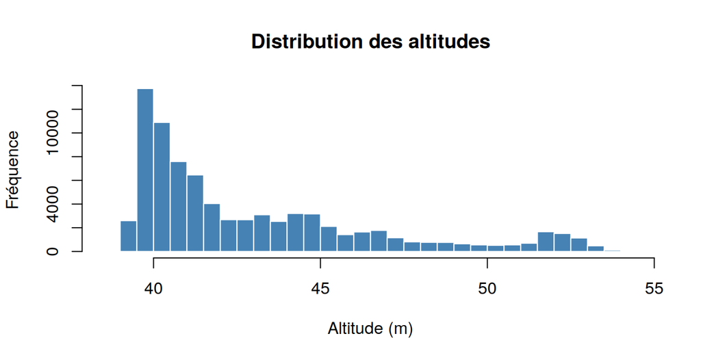

```r
hist(mnt, breaks = 40, col = "steelblue", border = "white",
     main = "Distribution des altitudes", xlab = "Altitude (m)",
     ylab = "Fréquence")
```

## 2.1 Visualisation du MNT

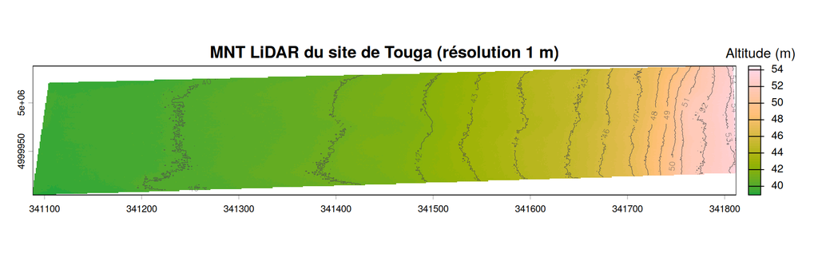

```r
plot(mnt, col = hcl.colors(50, "Terrain"),
     main = "MNT LiDAR du site de Touga (résolution 1 m)",
     plg = list(title = "Altitude (m)"))
contour(mnt, add = TRUE, nlevels = 12, col = "grey30", lwd = 0.5)
```

L’**ombrage** (hillshade) simule un éclairage oblique du relief et met en évidence les micro-formes du terrain — talwegs, buttes, fossés — souvent invisibles sur une simple carte d’altitude.

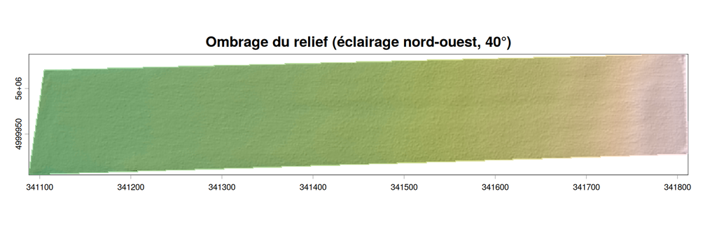

```r
pente_rad  <- terrain(mnt, v = "slope",  unit = "radians")
expo_rad   <- terrain(mnt, v = "aspect", unit = "radians")
ombrage    <- shade(pente_rad, expo_rad, angle = 40, direction = 315)

plot(ombrage, col = grey.colors(100, 0, 1), legend = FALSE,
     main = "Ombrage du relief (éclairage nord-ouest, 40°)")
plot(mnt, col = hcl.colors(50, "Terrain"), alpha = 0.45, add = TRUE,
     legend = FALSE)
```

# 3 Indices topographiques

La fonction `terrain()` dérive les principaux indices morphométriques directement du MNT. Chaque indice éclaire une facette différente du relief.

## 3.1 Pente

La pente conditionne le ruissellement, l’érosion et la portance des machines. On la calcule en degrés puis on la convertit en pourcentage, unité usuelle en agronomie et en conservation des sols.

```r
pente_deg <- terrain(mnt, v = "slope", unit = "degrees")
pente_pct <- tan(pente_rad) * 100
names(pente_pct) <- "pente_pct"

global(pente_pct, c("mean", "max"), na.rm = TRUE)
```

```
#>               mean      max
#> pente_pct 3.122246 51.36683
```

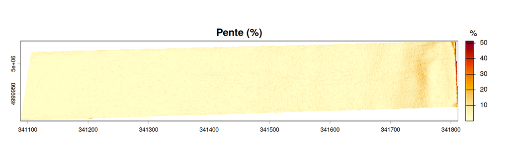

```r
plot(pente_pct, col = hcl.colors(50, "YlOrRd", rev = TRUE),
     main = "Pente (%)", plg = list(title = "%"))
```

## 3.2 Exposition

L’exposition (orientation de la pente par rapport au nord) influence l’ensoleillement, la fonte des neiges et l’évapotranspiration.

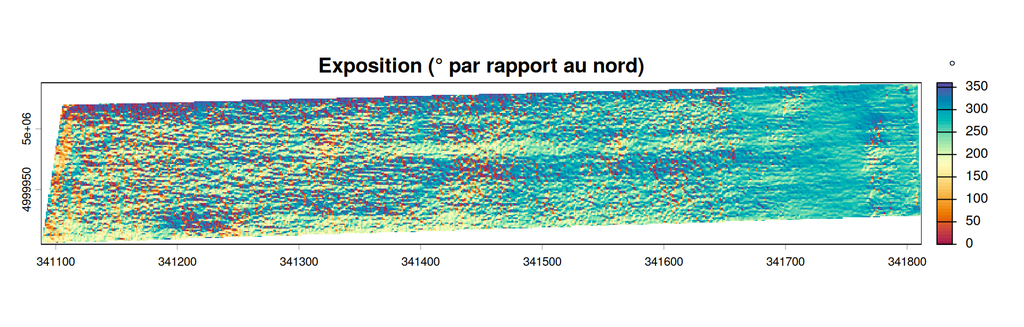

```r
expo_deg <- terrain(mnt, v = "aspect", unit = "degrees")
plot(expo_deg, col = hcl.colors(50, "Spectral"),
     main = "Exposition (° par rapport au nord)",
     plg = list(title = "°"))
```

## 3.3 TPI, TRI et rugosité

Le **TPI** (*Topographic Position Index*) compare l’altitude d’une cellule à la moyenne de ses voisines : les valeurs positives indiquent les buttes et les crêtes, les valeurs négatives les creux et les talwegs. Le **TRI** (*Terrain Ruggedness Index*) et la **rugosité** quantifient l’hétérogénéité locale du relief.

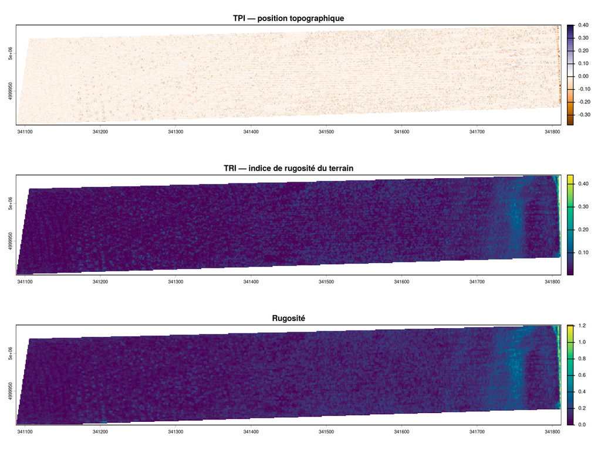

```r
tpi  <- terrain(mnt, v = "TPI")
tri  <- terrain(mnt, v = "TRI")
rugo <- terrain(mnt, v = "roughness")

par(mfrow = c(3, 1), mar = c(2, 2, 2.5, 6))
plot(tpi,  col = hcl.colors(50, "PuOr"),   main = "TPI — position topographique")
plot(tri,  col = hcl.colors(50, "Viridis"), main = "TRI — indice de rugosité du terrain")
plot(rugo, col = hcl.colors(50, "Viridis"), main = "Rugosité")
```

```r
par(mfrow = c(1, 1))
```

# 4 Analyse hydrologique

## 4.1 Correction des cuvettes (dépressions parasites)

Un MNT LiDAR à haute résolution contient de nombreuses **cuvettes** (*pits*) : des cellules plus basses que toutes leurs voisines, souvent des artefacts du levé, qui interrompent artificiellement les trajectoires d’écoulement. Avant tout calcul hydrologique, on les identifie avec `pitfinder()` puis on les comble avec `pitfiller()`.

```r
fd_brut  <- flowDir(mnt)          # directions d'écoulement sur le MNT brut
cuvettes <- pitfinder(fd_brut)    # localisation des cuvettes
cat("Nombre de cellules en cuvette :", sum(values(cuvettes) > 0, na.rm = TRUE), "\n")
```

```
#> Nombre de cellules en cuvette : 5639
```

```r
mnt_corr <- pitfiller(mnt, cuvettes)   # MNT hydrologiquement corrigé
remblai  <- mnt_corr - mnt
global(remblai, "max", na.rm = TRUE)   # hauteur maximale de remblai (m)
```

```
#>               max
#> altitude 0.378045
```

Le remblai maximal reste inférieur à 0,4 m : la correction est légère et ne déforme pas le terrain. Pour des applications de production sur de grands territoires, des algorithmes plus élaborés de comblement ou de *breaching* (p. ex. WhiteboxTools) sont recommandés; l’approche de `terra` suffit ici pour la démonstration.

## 4.2 Directions d’écoulement et accumulation de flux

`flowDir()` attribue à chaque cellule la direction de plus forte descente (modèle **D8**), puis `flowAccumulation()` compte le nombre de cellules amont qui se déversent dans chaque cellule. Multipliée par la surface d’une cellule (1 m²), cette valeur donne l’**aire drainée**.

```r
fd   <- flowDir(mnt_corr)
facc <- flowAccumulation(fd)               # nombre de cellules amont
aire <- facc * prod(res(mnt))              # aire drainée (m²)
names(aire) <- "aire_drainee_m2"

global(aire, "max", na.rm = TRUE)          # aire drainée maximale (m²)
```

```
#>                  max
#> aire_drainee_m2 6361
```

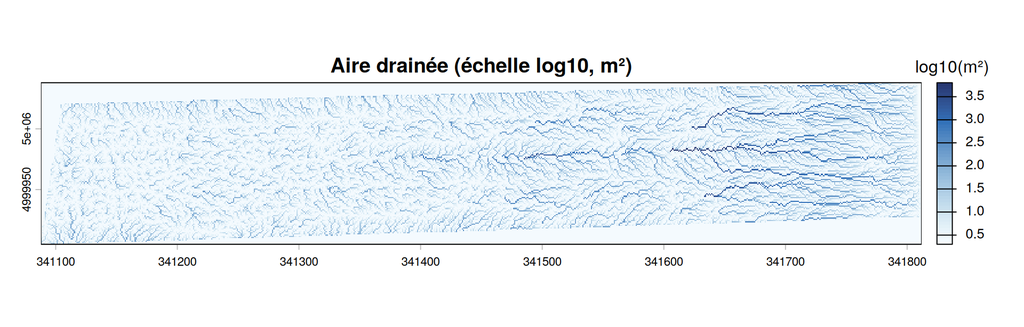

```r
plot(log10(aire + 1), col = hcl.colors(50, "Blues", rev = TRUE),
     main = "Aire drainée (échelle log10, m²)",
     plg = list(title = "log10(m²)"))
```

L’échelle logarithmique est indispensable : la distribution de l’accumulation est extrêmement asymétrique, quelques cellules de talweg concentrant l’écoulement de milliers de cellules amont.

## 4.3 Indice topographique d’humidité (TWI)

Le TWI de Beven et Kirkby (1979) combine l’aire drainée spécifique $a$ (m² par mètre de largeur d’écoulement) et la pente locale $\beta$ :

$$TWI = \ln\!\left(\frac{a}{\tan
\beta}\right)$$

Les fortes valeurs signalent les zones d’accumulation d’eau — sols humides, zones à risque de saturation — et les faibles valeurs les zones bien drainées.

```r
pente_corr <- terrain(mnt_corr, v = "slope", unit = "radians")
pente_min  <- clamp(pente_corr, 0.001, Inf)   # évite la division par zéro
a_spec     <- (facc + 1) * res(mnt)[1]        # aire drainée spécifique (m²/m)
twi        <- log(a_spec / tan(pente_min))
names(twi) <- "TWI"

global(twi, c("min", "max", "mean"), na.rm = TRUE)
```

```
#>          min      max    mean
#> TWI 1.430438 13.90582 5.43125
```

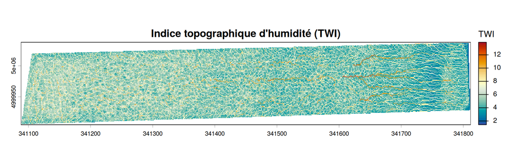

```r
plot(twi, col = hcl.colors(50, "RdYlBu", rev = TRUE),
     main = "Indice topographique d'humidité (TWI)",
     plg = list(title = "TWI"))
```

## 4.4 Extraction du réseau de drainage

On extrait le réseau de drainage en ne conservant que les cellules dont l’aire drainée dépasse un **seuil d’initiation** — ici 250 m², à ajuster selon le contexte (un seuil plus bas densifie le réseau).

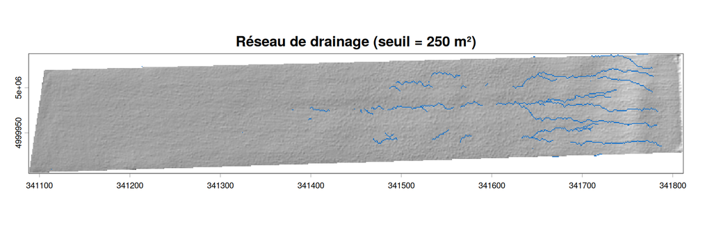

```r
seuil  <- 250   # m² d'aire drainée minimale
reseau <- ifel(aire >= seuil, 1, NA)

plot(ombrage, col = grey.colors(100, 0, 1), legend = FALSE,
     main = paste0("Réseau de drainage (seuil = ", seuil, " m²)"))
plot(reseau, col = "dodgerblue3", add = TRUE, legend = FALSE)
```

## 4.5 Délimitation du bassin versant

`watershed()` délimite l’ensemble des cellules qui s’écoulent vers un **exutoire** donné. On choisit ici la cellule d’accumulation maximale, c’est-à-dire l’exutoire principal du site.

```r
i_exut  <- which.max(values(facc))
xy_exut <- xyFromCell(facc, i_exut)
xy_exut
```

```
#>             x       y
#> [1,] 341605.4 4999981
```

```r
bassin <- watershed(fd, xy_exut)
bassin <- ifel(bassin == 1, 1, NA)

sup_ha <- sum(values(bassin) == 1, na.rm = TRUE) * prod(res(mnt)) / 1e4
cat("Superficie du bassin versant :", round(sup_ha, 2), "ha\n")
```

```
#> Superficie du bassin versant : 0.64 ha
```

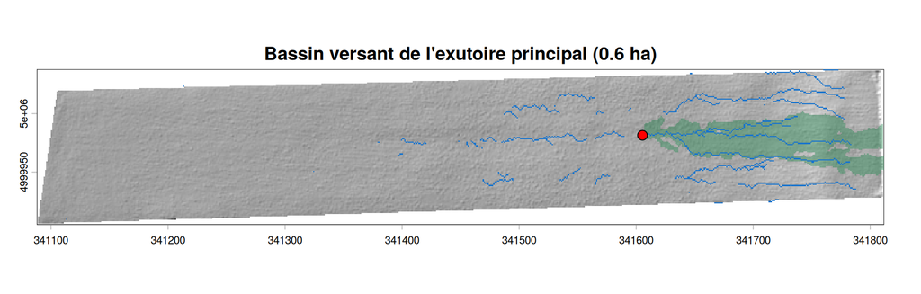

```r
plot(ombrage, col = grey.colors(100, 0, 1), legend = FALSE,
     main = paste0("Bassin versant de l'exutoire principal (",
                   round(sup_ha, 1), " ha)"))
plot(bassin, col = adjustcolor("seagreen", 0.45), add = TRUE, legend = FALSE)
plot(reseau, col = "dodgerblue3", add = TRUE, legend = FALSE)
points(xy_exut, pch = 21, bg = "red", cex = 1.4)
```

# 5 Estimation du risque d’érosion hydrique

## 5.1 Facteur topographique LS

Le facteur LS de l’équation universelle de perte de sol combine l’effet de la longueur de pente (via l’aire drainée spécifique $A_s$) et de l’inclinaison $\beta$. On utilise la formulation de Moore et Burch (1986), bien adaptée aux MNT :

$$LS =
\left(\frac{A_s}{22{,}13}\right)^{0{,}4} \times \left(\frac{\sin
\beta}{0{,}0896}\right)^{1{,}3}$$

```r
LS <- (a_spec / 22.13)^0.4 * (sin(pente_min) / 0.0896)^1.3
names(LS) <- "LS"

global(LS, c("mean", "max"), na.rm = TRUE)
```

```
#>         mean      max
#> LS 0.1914248 8.643975
```

Dans les talwegs, l’aire drainée devient très grande et la formule surestime le LS : l’écoulement y est concentré (risque de ravinement) et ne relève plus de l’érosion en nappe décrite par RUSLE. On masque donc le réseau de drainage pour cartographier l’érosion en nappe et rigoles sur les versants.

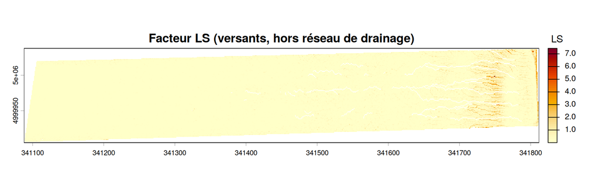

```r
LS_versant <- mask(LS, reseau, inverse = TRUE)   # LS hors réseau de drainage

plot(LS_versant, col = hcl.colors(50, "YlOrRd", rev = TRUE),
     main = "Facteur LS (versants, hors réseau de drainage)",
     plg = list(title = "LS"))
```

## 5.2 Application de l’équation RUSLE

RUSLE estime la perte de sol annuelle moyenne $A$ (t·ha⁻¹·an⁻¹) :

$$A = R \times K \times LS \times C \times
P$$

Les valeurs ci-dessous sont **indicatives** pour un contexte agricole du sud du Québec et doivent être ajustées au site (données pédologiques, cultures et pratiques réelles) : $R$ = 1200 MJ·mm·ha⁻¹·h⁻¹·an⁻¹ (érosivité des pluies), $K$ = 0,035 t·ha·h·ha⁻¹·MJ⁻¹·mm⁻¹ (loam), $C$ = 0,25 (grandes cultures en rangs) et $P$ = 1 (aucune pratique antiérosive).

```r
R_pluie  <- 1200    # MJ·mm/(ha·h·an)
K_sol    <- 0.035   # t·ha·h/(ha·MJ·mm)
C_culture<- 0.25    # sans dimension
P_prat   <- 1       # sans dimension

A_perte <- R_pluie * K_sol * LS_versant * C_culture * P_prat
names(A_perte) <- "perte_sol_t_ha_an"

global(A_perte, c("mean", "max"), na.rm = TRUE)
```

```
#>                       mean      max
#> perte_sol_t_ha_an 1.740433 78.07309
```

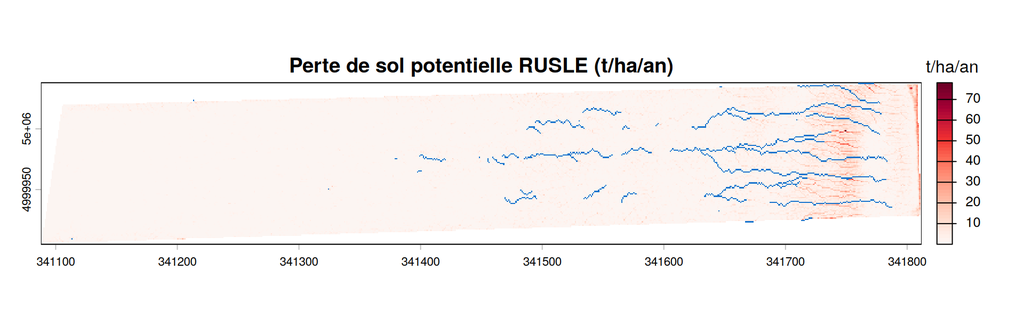

```r
plot(A_perte, col = hcl.colors(50, "Reds", rev = TRUE),
     main = "Perte de sol potentielle RUSLE (t/ha/an)",
     plg = list(title = "t/ha/an"))
plot(reseau, col = "dodgerblue3", add = TRUE, legend = FALSE)
```

## 5.3 Classes de risque d’érosion

On reclasse la perte de sol selon les seuils usuels de sévérité (t·ha⁻¹·an⁻¹) : très faible (< 6), faible (6–11), modéré (11–22), élevé (22–33) et très élevé (> 33).

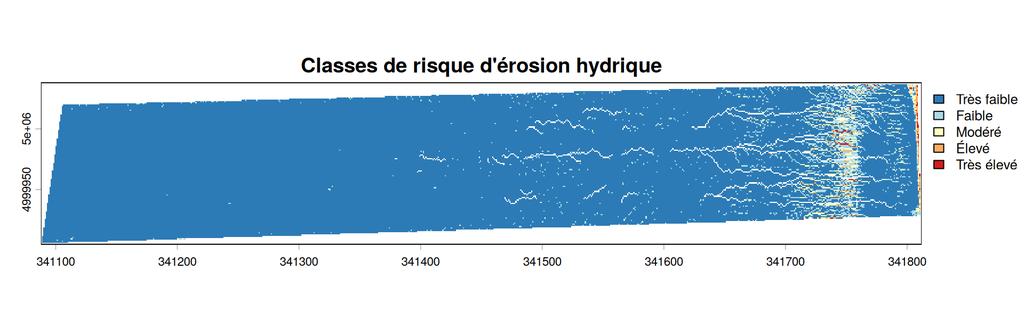

```r
seuils  <- matrix(c(-Inf, 6, 1,
                     6,  11, 2,
                    11,  22, 3,
                    22,  33, 4,
                    33, Inf, 5), ncol = 3, byrow = TRUE)
classes <- classify(A_perte, seuils)
niveaux <- data.frame(id = 1:5,
                      classe = c("Très faible", "Faible", "Modéré",
                                 "Élevé", "Très élevé"))
levels(classes) <- niveaux

plot(classes,
     col = c("#2c7bb6", "#abd9e9", "#ffffbf", "#fdae61", "#d7191c"),
     main = "Classes de risque d'érosion hydrique")
```

```r
f <- freq(classes)
f$surface_ha <- round(f$count * prod(res(mnt)) / 1e4, 2)
f$pourcent   <- round(100 * f$count / sum(f$count), 1)
knitr::kable(f[, c("value", "surface_ha", "pourcent")],
             col.names = c("Classe de risque", "Surface (ha)", "% du site"),
             caption = "Répartition des superficies par classe de risque d'érosion")
```

Répartition des superficies par classe de risque d’érosion

| Classe de risque | Surface (ha) | % du site |
| --- | --- | --- |
| Très faible | 7.41 | 94.9 |
| Faible | 0.26 | 3.3 |
| Modéré | 0.11 | 1.4 |
| Élevé | 0.03 | 0.4 |
| Très élevé | 0.01 | 0.1 |

# 6 Exportation des résultats

Toutes les couches produites peuvent être exportées en GeoTIFF pour être réutilisées dans un SIG (QGIS, ArcGIS) ou dans une analyse ultérieure.

```r
resultats <- c(mnt_corr, pente_pct, twi, aire, LS, A_perte)
names(resultats) <- c("mnt_corrige", "pente_pct", "TWI",
                      "aire_drainee_m2", "LS", "perte_sol_t_ha_an")
writeRaster(resultats, "resultats_Touga.tif", overwrite = TRUE)
list.files(pattern = "^resultats")
```

```
#> [1] "resultats_Touga.tif"
```

# 7 Synthèse et pistes d’exercices

Quelques prolongements possibles pour aller plus loin : faire varier le seuil d’initiation du réseau de drainage (50, 100, 500 m²) et observer son effet sur la densité du réseau et sur le facteur LS; comparer le TWI avec une carte de matière organique ou de rendement pour vérifier la cohérence des zones humides prédites; recalculer la perte de sol RUSLE avec un facteur $C$ correspondant à une prairie ($C \approx 0{,}02$) ou à un semis direct, et quantifier la réduction du risque; enfin, délimiter le bassin versant d’un autre exutoire choisi interactivement avec `click()`.

# 8 Références

Beven, K. J. et Kirkby, M. J. (1979). A physically based, variable contributing area model of basin hydrology. *Hydrological Sciences Bulletin*, 24(1), 43–69.

Hijmans, R. J. (2026). *terra: Spatial Data Analysis*. R package. https://rspatial.org/

Moore, I. D. et Burch, G. J. (1986). Physical basis of the length-slope factor in the Universal Soil Loss Equation. *Soil Science Society of America Journal*, 50(5), 1294–1298.

Renard, K. G., Foster, G. R., Weesies, G. A., McCool, D. K. et Yoder, D. C. (1997). *Predicting Soil Erosion by Water: A Guide to Conservation Planning with the Revised Universal Soil Loss Equation (RUSLE)*. USDA Agriculture Handbook 703.

Wall, G. J., Coote, D. R., Pringle, E. A. et Shelton, I. J. (2002). *RUSLE-CAN — Équation universelle révisée des pertes de sol pour application au Canada*. Agriculture et Agroalimentaire Canada.

Wischmeier, W. H. et Smith, D. D. (1978). *Predicting Rainfall Erosion Losses: A Guide to Conservation Planning*. USDA Agriculture Handbook 537.

```
#> Document généré avec R 4.3.3 et terra 1.9.46
```